# Brasil x Polônia: uma análise de gasto educacional e desempenho econômico

Julia Teixeira

2025-09-26

# Objetivo

Analisar e comparar Brasil e Polônia entre 1990–2019, integrando duas bases de dados (Penn World Table e World Development Indicators), com foco em **crescimento econômico** e **gasto em educação**. O trabalho busca entender por que a Polônia apresentou trajetória de crescimento superior, destacando o papel de educação, políticas institucionais e eficiência no uso dos recursos.

## Leitura das bases brutas

```r
# Primeiro, criei variáveis com os caminhos dos arquivos

# wdid_path <- caminho do arquivo
# wdim_path <- caminho do arquivo
# pwt_path  <- caminho do arquivo

# Em seguida, importo as bases de dados usando a função read_csv

wdi_data <- read_csv(wdid_path)
wdi_meta <- read_csv(wdim_path)
pwt      <- read_csv(pwt_path)
```

## Limpeza (PWT) e variáveis derivadas

```r
# Seleciono colunas essenciais
pwt_min <- pwt %>%
  select(
    year, country_id_iso_3, country,
    real_gdp_expenditures, real_gdp_output,
    current_share_gcf, current_capital_stock,
    current_share_x, current_share_m,
    employees, population
  ) %>%
  mutate(
    year = as.integer(year),
    gdp_pc = real_gdp_expenditures / population,          # PIB per capita (PPP, lado despesa)
    gdp_per_worker = real_gdp_expenditures / employees    # Produtividade do trabalho
  )

# Brasil & Polônia, 1990–2019
pwt_br_pol <- pwt_min %>%
  filter(
    country_id_iso_3 %in% c("BRA", "POL"),
    between(year, 1990, 2019)
  ) %>%
  arrange(country_id_iso_3, year)
```

## Limpeza (WDI) e seleção das séries de educação

```r
# Removo linhas sem dados quantificados
wdi_data <- wdi_data %>%
  slice(-c(19:23))

# Capturo colunas de anos e mantém 1990–2019
cols_anos <- names(wdi_data)[5:ncol(wdi_data)]
cols_anos <- cols_anos[cols_anos %in% paste0(1990:2019, " [YR", 1990:2019, "]")]

# Long: (país, série, ano, valor)
wdi_long <- wdi_data %>%
  dplyr::select(`Country Name`, `Country Code`, `Series Name`, `Series Code`, dplyr::all_of(cols_anos)) %>%
  tidyr::pivot_longer(
    cols      = dplyr::all_of(cols_anos),
    names_to  = "year",
    values_to = "value"
  ) %>%
  dplyr::mutate(
    year  = as.integer(substr(year, 1, 4)),                     # extraindo "1990" de "1990 [YR1990]"
    value = readr::parse_number(value, na = c("..", "NA", ""))  # tratando ".." como NA
  )

# As 9 séries educacionais
educ_codes <- c(
  "SE.SEC.CUAT.PO.ZS",  # pós-sec. completo (25+), %
  "SE.SEC.CUAT.UP.ZS",  # médio completo (25+), %
  "SE.TER.CUAT.BA.ZS",  # bacharel completo (25+), %
  "SE.TER.CUAT.ST.ZS",  # terciário curto completo (25+), %
  "SE.XPD.CSEC.ZS",     # gasto corrente - secundário (% do gasto público em instituições públicas)
  "SE.XPD.CTER.ZS",     # gasto corrente - superior   (% do gasto público em instituições públicas)
  "SE.XPD.CTOT.ZS",     # gasto corrente - total      (% do gasto público em instituições públicas)
  "SE.XPD.TOTL.GB.ZS",  # gasto total educação (% do gasto do governo)
  "SE.XPD.TOTL.GD.ZS"   # gasto total educação (% do PIB)
)

# Mantendo BR/POL + 9 séries; deixa em WIDE usando os códigos como nomes de coluna
wdi_wide <- wdi_long %>%
  filter(`Country Code` %in% c("BRA","POL"),
         `Series Code` %in% educ_codes,
         between(year, 1990, 2019)) %>%
  select(`Country Code`, year, `Series Code`, value) %>%
  pivot_wider(names_from = `Series Code`, values_from = value) %>%
  rename(country_id_iso_3 = `Country Code`)

# Renomeando variáveis-chave para nomes fáceis
wdi_wide <- wdi_wide %>% rename(
  ed_spend_gdp   = `SE.XPD.TOTL.GD.ZS`, # gasto total educ (% do PIB)
  ed_spend_gov   = `SE.XPD.TOTL.GB.ZS`, # gasto total educ (% do gasto do governo)
  sec_complete_25= `SE.SEC.CUAT.UP.ZS`, # médio completo (25+)
  postsec_25     = `SE.SEC.CUAT.PO.ZS`, # pós-sec completo (25+)
  ter_ba_25      = `SE.TER.CUAT.BA.ZS`, # bacharel completo (25+)
  ter_short_25   = `SE.TER.CUAT.ST.ZS`, # terciário curto completo (25+)
  cur_spend_sec  = `SE.XPD.CSEC.ZS`,    # gasto corrente sec (% inst púb)
  cur_spend_ter  = `SE.XPD.CTER.ZS`,    # gasto corrente ter (% inst púb)
  cur_spend_tot  = `SE.XPD.CTOT.ZS`     # gasto corrente total (% inst púb)
)
```

## Integração (join) — painel Brasil x Polônia

```r
# Join reprodutível por país (ISO3) e ano
panel <- pwt_br_pol %>%
  left_join(wdi_wide, by = c("country_id_iso_3", "year")) %>%
  arrange(country_id_iso_3, year)

# Índice de PIB pc = 100 no primeiro ano observado (1990)
panel <- panel %>%
  group_by(country_id_iso_3) %>%
  arrange(year, .by_group = TRUE) %>%
  mutate(gdp_pc_idx_1990 = 100 * gdp_pc / first(gdp_pc)) %>%
  ungroup()
```

# Gráfico 1 — PIB per capita (PPP), índice 1990=100

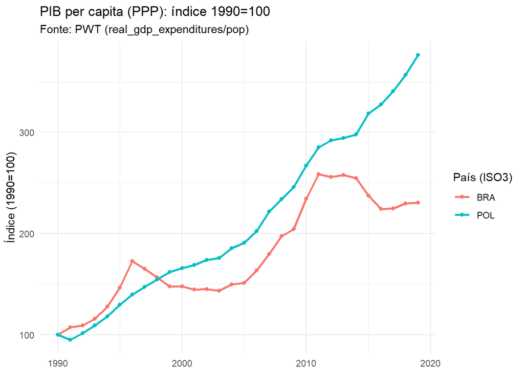

```r
plt1 <- ggplot(panel, aes(x = year, y = gdp_pc_idx_1990, color = country_id_iso_3)) +
  geom_line(linewidth = 1) +
  geom_point(size = 1.5) +
  scale_y_continuous(labels = function(x) paste0(x)) +
  labs(title = "PIB per capita (PPP): índice 1990=100",
       subtitle = "Fonte: PWT (real_gdp_expenditures/pop)",
       x = NULL, y = "Índice (1990=100)", color = "País (ISO3)") +
  theme_minimal()
plt1
```

**Leitura:** Ao longo de 1990–2019, a curva da Polônia (POL) sobe mais rápido e atinge valores bem mais altos que a curva do Brasil (BRA).

- Brasil: o PIB per capita cresceu, mas de forma lenta e irregular (anos de estagnação e crises).
- Polônia: desde os anos 1990, apresentou crescimento mais constante, sem grandes períodos de queda, puxando o índice para cima.

  Se em 1990 Brasil e Polônia estavam em níveis parecidos, em 2019 a Polônia se distanciou — ou seja, aumentou sua renda relativa em comparação ao Brasil.

  *O PIB per capita foi calculado indexado a 1990 = 100.*

# Gráfico 2 — Gasto total em educação (% do PIB)

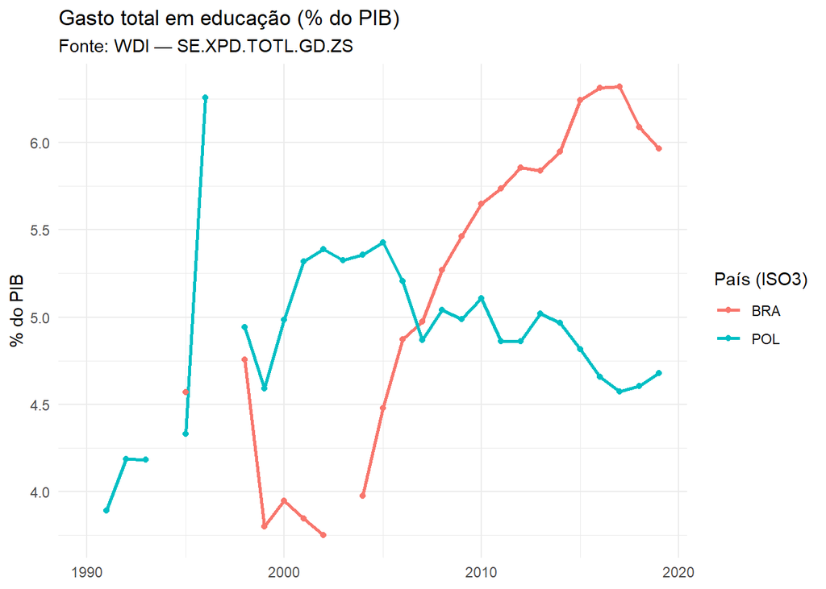

```r
plt2 <- ggplot(panel, aes(x = year, y = ed_spend_gdp, color = country_id_iso_3)) +
  geom_line(linewidth = 1) +
  geom_point(size = 1.5) +
  labs(title = "Gasto total em educação (% do PIB)",
       subtitle = "Fonte: WDI — SE.XPD.TOTL.GD.ZS",
       x = NULL, y = "% do PIB", color = "País (ISO3)") +
  theme_minimal()
plt2
```

Portanto, não basta olhar só para o percentual gasto. O dado mostra que a Polônia conseguiu transformar níveis de gasto em melhor desempenho econômico, enquanto o Brasil não teve a mesma eficiência.

## Glossário (pós-limpeza)

| Variável | Fonte | Descrição |
| --- | --- | --- |
| `country_id_iso_3` | PWT/WDI | Código de país ISO3 (“BRA”, “POL”) |
| `year` | PWT/WDI | Ano calendário |
| `gdp_pc` | PWT | PIB per capita (PPP) = `real_gdp_expenditures/population` |
| `gdp_pc_idx_1990` | derivada | Índice de PIB pc (1990=100) para comparar trajetórias |
| `ed_spend_gdp` | WDI | `SE.XPD.TOTL.GD.ZS` — Gasto total em educação (% do PIB) |
| `ed_spend_gov` | WDI | `SE.XPD.TOTL.GB.ZS` — Gasto educação (% do gasto do governo) |
| `sec_complete_25` | WDI | `SE.SEC.CUAT.UP.ZS` — Médio completo (25+) |
| `postsec_25` | WDI | `SE.SEC.CUAT.PO.ZS` — Pós-sec completo (25+) |
| `ter_ba_25` | WDI | `SE.TER.CUAT.BA.ZS` — Bacharel completo (25+) |
| `ter_short_25` | WDI | `SE.TER.CUAT.ST.ZS` — Terciário curto completo (25+) |
| `cur_spend_sec` | WDI | `SE.XPD.CSEC.ZS` — Gasto corrente secundário (% gasto púb em inst púb) |
| `cur_spend_ter` | WDI | `SE.XPD.CTER.ZS` — Gasto corrente superior (% gasto púb em inst púb) |
| `cur_spend_tot` | WDI | `SE.XPD.CTOT.ZS` — Gasto corrente total (% gasto púb em inst púb) |

## Validação e origem das bases

- **PWT — Penn World Table 10.x via Base dos Dados**: conjunto hospedado pela Base dos Dados (Universidade de Groningen como fonte original). O link informado pelo projeto: *Penn World Tables (PWT) – Base dos Dados*. Os arquivos utilizados aqui foram exportados localmente a partir dessa fonte (ver `pwt_path`).
- **WDI — World Development Indicators (Banco Mundial)**: acessado pelo portal oficial do World Bank / DataBank (CSV exportado), incluindo metadados em `wdim_path`.

Ambas as origens são públicas e versionadas.

## Referências e trechos reutilizados

### Bases de dados

- Penn World Table (PWT 10.x) – fonte original: University of Groningen / GGDC.
  - Acessei via Base dos Dados.
- World Development Indicators (WDI) – fonte original: World Bank DataBank.

### Fontes

Cavalcanti, P., & Fragelli, R. (2025, July 24). Milagres, desastres e estagnação. Valor Econômico.

Kunsch, M., Cunha, M., & Barcellos, L. (n.d.). *Ciência de Dados em R*. Curso-R. Retrieved September 30, 2025, from https://livro.curso-r.com/

### Pacotes R usados

- tidyverse (dplyr, tidyr, ggplot2, readr, etc.)

### Metodologia / pipeline

- Funções básicas do dplyr (mutate, filter, select, arrange, left_join)
- Transformações com tidyr (pivot_longer, pivot_wider)
- Visualização com ggplot2

## Divulgação de IA

Usei auxílio de IA (ChatGPT) **apenas** para organizar o pipeline e comentários. Prompts principais: “usar meus CSVs locais; operador pipe; dois gráficos simples; glossário.